# econ2200Ch05 slides

## ECON2200H

### Introduction to Statistics for Economics and Management

### 2020 Winter Term

### Week 04: Random Variables and Their Distributions (revised)

#### 29 January 2020

### Reading: Chapters 5 of textbook.

## Outline

- Random variables
- Probability distribution
- Expected value, variance
- Some discrete probability distributions
- Some continuous probability distributions

## 1. Random variables

- Let $S$ be the sample space of an experiment, a **random variable** $X$ is a function from $S$ to the real numbers.
- That is, a random variable assigns a numerical value to each possible outcome in the sample space.
- Because the outcome of an experiment is random, the real number produced by the function is also random.
- **Example**. Tossing a coin three times, sample space $S$ = {HHH, HHT, HTT, HTH, TTT, TTH, THH, THT}.
  - The total number of heads is a random variable. It takes values 0, 1, 2, or 3.
- If outcome $s$ is the sequence HTH, then $X(s) = 2$.
- If outcome $s$ is the sequence TTT, then $X(s) = 0$.
- In the above example, the number of heads minus the number of tails is also a random variable. It takes values of -3, -1, 1, or 3.
- More examples of random variables:
  - The lifetime of a new battery.
  - The winning number of LOTT 6/49.
  - The amount of rainfall in Peterborough.

## 2. Discrete random variables and their distributions

- A random variable is **discrete** if it takes on only a finite number of values, or, at most, a countably infinite number of values.
- Random variables defined in the previous example are discrete.
- We are interested in the probability of a random variable.
- **Example**. Tossing a coin three times. Let $X$ = the total number of heads. $S$ = {HHH, HHT, HTH, HTT, TTT, TTH, THT, THH}.

| Outcomes of event | {TTT} | {HTT, TTH, THT} | {HHT, HTH, THH} | {HHH} |
| --- | --- | --- | --- | --- |
| $x$ | $0$ | $1$ | $2$ | $3$ |
| $P(X=x)$ | $\frac{1}{8}$ | $\frac{3}{8}$ | $\frac{3}{8}$ | $\frac{1}{8}$ |

- **Example** (continued). Let $X$= the number of heads minus the number of tails.

| Outcomes of event | {TTT} | {HTT, TTH, THT} | {HHT, HTH, THH} | {HHH} |
| --- | --- | --- | --- | --- |
| $x$ | $-3$ | $-1$ | $1$ | $3$ |
| $P(X=x)$ | $\frac{1}{8}$ | $\frac{3}{8}$ | $\frac{3}{8}$ | $\frac{1}{8}$ |

### 2-1. The probability mass function

- The **distribution** of a random variable $X$ is the collection of probabilities $P(X = x)$ for all values of real variable $x$.
- The distribution of $X$ shows all values of the pair $(x, P(X=x))$.
- For a discrete random variable $X$, the **probability mass function** of $X$ is defined as the function $f$, such that for every real number $x$, $f(x) = P(X=x)$.
- Some also refer to the probability mass function as the **probability function**.
- The **support** of $X$ is the set of real numbers $x_i$ with $P(X=x_i)>0$, for all $i$.
- Let $x_1, x_2, \cdots$ be the support of $X$, the probability mass function satisfies the following.

  1). $f(x) > 0$ if $x=x_j$ is in the support of $X$, and $f(x)=0$ otherwise.

  2). $\sum_{i=1}^{\infty} f(x_i)=1$.
- **Example**. Roll two dice. Let $X$ be the sum of the two numbers that appear.

[figure not shown]

- $X$ can take values of $2,3,\cdots,12$.

| $\quad \quad x$ | 2 | 3 | 4 | 5 | 6 | 7 | 8 | 9 | 10 | 11 | 12 |
| --- | --- | --- | --- | --- | --- | --- | --- | --- | --- | --- | --- |
| $P(X=x)$ | 1/36 | 2/36 | 3/36 | 4/36 | 5/36 | 6/36 | 5/36 | 4/36 | 3/36 | 2/36 | 1/36 |

- The probability mass function is $f(x) = P(X=x)$, and $f(x) = \left\{\begin{array}{lr} 1/36, & \text{if } x =2 \\ 2/36, & \text{if } x=3 \\ \vdots & \end{array} \right.$.
- Clearly, $\sum_{i=1} f(x_i) = 1$.

### 2-2. Cumulative distribution function

- The **cumulative distribution function** (cdf) of a random variable $X$ is defined as $$F(x) = P(X \le x), \quad \text{for} \ -\infty \le x \le \infty.$$
- This defintion applies to any random variables, discrete or continuous.
- Properties of the cdf of a random variable $X$

  1). Non-decreasing with $x$, i.e., if $x_1 < x_2$, then $F(x_1) \le F(x_2)$.

  2). $\lim_{x\rightarrow -\infty} F(x) = 0$ and $\lim_{x\rightarrow \infty} F(x) =1$.

### 2-3. Independence of random variables

- Let $X$ be a random variable, taking on values of $x_1, x_2, \cdots$; let $Y$ be another random variable, taking on values of $y_1, y_2, ...$.
- $X$ and $Y$ are said to be **independent** if, for all $i$ and $j$, $$P(X=x_i \ \text{and} \ Y= y_j) = P(X=x_i) \cdot P(Y=y_j).$$
- This definition applies to both discrete and continuous random variables.

### 2-4. Mean and variance of a discrete random variable

- Let $X$ be a discrete random variable. The **expected value** or **mean** of $X$ is

$$E [X] = \sum_{i=1}^{\infty} x_i P(X=x_i).$$

- We often use $\mu$ for $E [X] $. Sometimes we write $EX$ instead of $E[X]$.
- If $Y = a X + b$ where $a, b$ are finite constants, then $$EY = aEX+b.$$
- For any two random variables $X$ and $Y$, $$E[X+Y] = EX + EY.$$
- The **variance** of any random variable $X$ is the expected value of $(X-EX)^2$, that is, $\text{var}(X) = E[(X-EX)^2]$.
- For a discrete random variable $X$, $$\text{var}(X) = \sum_{i=1}^{\infty} (x_i- \mu )^2 P(X=x_i).$$
- We often use $\sigma^2$ for $\text{var}(X)$.
- It can be shown that $$\text{var}(X) = E[X^2] - (E[X])^2.$$
- If $Y = a X + b$ where $a, b$ are finite constants, then $$\text{var}(Y) = a^2 \text{var}(X).$$
- If random variables $X_1$ and $X_2$ are independent, then $$\text{var}(X_1+X_2) = \text{var}(X_1) + \text{var}(X_2).$$

## 3. Examples of discrete distributions

### 3-1. Geometric distribution

- In an experiment with two outcomes: success or failure, the probability of success is $p$. Repeat the experiment until a success occurs, the number of trials, $N$, is a discrete random variable. The distribution of $N$ is $$f(n) = P(N=n) = (1-p)^{n-1} \cdot p.$$
- Why? There are (n-1) trials with a failure, followed by a success in the $n$-th trial.
- Example. Tossing a coin. In each trial, the probability of a head is 1/2. The number of tosses until a first head follows a geometric distribution, $P(N=n) = \left(1-\frac{1}{2}\right)^{n-1} \cdot \frac{1}{2}$.
- What is the probability of obtaining the first head in the 5th trial? $P(N=5) = \left(1-\frac{1}{2}\right)^4 \cdot \frac{1}{2} = \left( \frac{1}{2}\right)^5 = 0.03125$.

### 3-2. Bernoulli distribution

- A random variable $X$ that takes only two values $0$ and $1$ with $P(X=1)=p$ has the **Bernoulli distribution with parameter $p$**.
- We then can call $X$ a Bernoulli random variable.
- The probability mass function of a Bernoulli random variable is $f(x) = (1-p)^{1-x} p^{x}$, with $x=0$ or $x=1$.
- In an experiment with two outcomes, we can code success to be 1 and failure to be 0.
- If $X$ has a Bernoulli distribution with $P(X=1) = p$, the expected value of $X$ is $EX = p$,
- and the variance of $X$ is $(1-p)p$.
- Because $\text{var}(X) = (0-p)^2 \cdot (1-p) + (1-p)^2 \cdot p = (1-p)p$.
- **Example**. Tossing a coin, let 1 represents a head with probability $p=1/2$, 0 a tail, with probability $(1-p)$. Then, random variable $X$ taking 1 or 0 is a Bernoulli random variable.

### 3-3. Binomial distribution

- Suppose that $n$ *independent* experiments (trials) are performed, and that each trial results in a "success" with probability $p$ and a "failure" with probability $1-p$.
- Each trial is a called a Bernoulli trial, because we can let 1="success" and 0="failure".
- The total number of successes in $n$ trials, $X$, is a random variable. $X$ has the **Binomial distribution with parameters $n$ and $p$**.
- The probability mass distribution of $X$ is then given by $$P(X=k) = \binom{n}{k} p^k (1-p)^{n-k}.$$
- Why? The probability of any specific sequence with $k$ successes and $n-k$ failures is $p^k (1-p)^{n-k}$. There are $\binom{n}{k}$ such sequences, since there are $\binom{n}{k}$ ways to assign $k$ successes to $n$ trials.
- Therefore, the probability of $k$ successes in $n$ trials is obtained by **adding** the probability $p^k (1-p)^{n-k}$ for all $\binom{n}{k}$ sequences.
- FYI. $P(X=k)$ is indeed a distribution. First, $P(X=k)\ge 0$. Second, by the Binomial Theorem, $(x+y)^n = \sum_{k=0}^n \binom{n}{k} x^k y^{n-k}$, we have $\sum_{k=0}^n \binom{n}{k} p^k (1-p)^{n-k}=1$ .
- **Example**. A machine produces a defective item with probability $p$. The number of defective items in $n$ items follows a binomial distribution.
- **Example**. Tossing a coin 5 times, what is the probability of obtaining 2 heads? $X$ is the number of heads. $p = 1/2$, $n=5$, $k=2$. Then $P(X=2) = C_{5,2} \left(\frac{1}{2}\right)^2 \left(1-\frac{1}{2}\right)^{5-2} = 0.3125$.
- The expected value of a binomial random variable $X$ is $EX = np$.
- It can be shown that the variance of $X$ is $\text{var}(X) = np (1-p)$.
- One way to understand: We can write $X = X_1+X_2+\cdots+X_n$ where $X_1, X_2,\cdots, X_n$ are independent random variables each having a Bernoulli distribution with parameter $p$. We know that $EX_1 =p, EX_2=p, \cdots$. Thus $EX = p+p+\cdots+p = np$.
- Recall that $\text{var}(X_1) = p(1-p), \text{var}(X_2) = p(1-p), \cdots$, and since $X_1, X_2, \cdots, X_n$ are independent, $\text{var}(X) = \text{var}(X_1)+ \text{var}(X_2)+ \cdots+\text{var}(X_n) = np(1-p)$.
- Probability mass distribution of a binomial random variable with $p = 0.1, n = 20$.

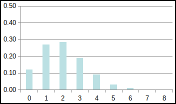

### 3-4. Hypergeometric distribution

- Suppose an urn contains $n$ balls, of which $r$ are black and $n-r$ are white. Let $X$ be the number of black balls drawn when taking $m$ balls without replacement.
- $X$ then has the **hypergeometric distribution with parameters $r$, $n$, and $m$**, $$P(X=k) = \frac{\binom{r}{k} \binom{n-r}{m-k}}{\binom{n}{m}}.$$

### 3-5. Poisson distribution

- A discrete random variable $X$ has the **Poisson distribution with parameter $\lambda$** where $\lambda>0$ if the probability mass function of $X$ is $$P(X=k) = \frac{\lambda^k e^{-\lambda}}{k!}, \quad \text{for} \ k = 0, 1, 2, \cdots. $$
- Here, $e = 2.71828$, sometimes called **Euler's number**. Fact: $\lim_{n\rightarrow \infty} \left(1+\frac{1}{n}\right)^n = e$.
- $\sum_{k=0}^{\infty} P(X=k) =1$, because $\sum_{k=0}^{\infty}\frac{\lambda^k }{k!}=e^{\lambda}$.
- The Poisson distribution is the limit of the binomial distribution as the number of trials, $n$, approaches to infinity and the probability of success on each trial, $p$, approaches to zero, in such a way that $np=\lambda$.
- (Optional) Proof: Let $n p = \lambda$, then $p = \frac{\lambda}{n}$, the binomial distribution function becomes $$P(X=k) = \frac{n!}{k! (n-k)!} \cdot \left(\frac{\lambda}{n}\right)^k \left(1-\frac{\lambda}{n}\right)^{n-k} \\ = \frac{\lambda^k}{k!} \cdot \frac{n!}{(n-k)! n^k} \cdot \left(1-\frac{\lambda}{n}\right)^{n} \cdot \left(1-\frac{\lambda}{n}\right)^{-k}.$$
- As $n \rightarrow \infty$, $\left(1-\frac{\lambda}{n}\right)^{n} \rightarrow e^{-\lambda}$, $\frac{n!}{(n-k)! n^k} \rightarrow 1$, and $\left(1-\frac{\lambda}{n}\right)^{-k} \rightarrow 1$.
- Therefore, as $n \rightarrow \infty$, $P(X=k) \rightarrow \frac{\lambda^k e^{-\lambda}}{k!}$ which is Poisson.
- Thus, we can use the Poisson distribution to approximate the binomial distribution for large $n$ and small $p$.
- Poisson distribution can be used in the following situation.
- Let $X$ be a random variable that equals the number of occurrences of some event in a given time interval. We can think of dividing the time interval into a large number of small sub-intervals of equal length, and assume that the sub-intervals are so small that the probability of more than one event in a sub-interval is negligible relative to the probability of one event which is itself very small.
- Also assume that the probability of an event is the same in each sub-interval, and whether an event occurs in one sub-interval is independent of occurring in other sub-intervals.
- $X$ then has approximately a Poisson distribution.
- The expected value of a Poisson random variable $X$ is $$E[X]= \lambda.$$
- Recall that the mean of a binomial variable is $np$. And for a Poisson random variable $X$, $\lambda = np$.
- Parameter $\lambda$ can be considered as the average number of occurrences.
- **The variance of $X$ is also $\lambda$**. Skipping the derivation.
- Some examples.

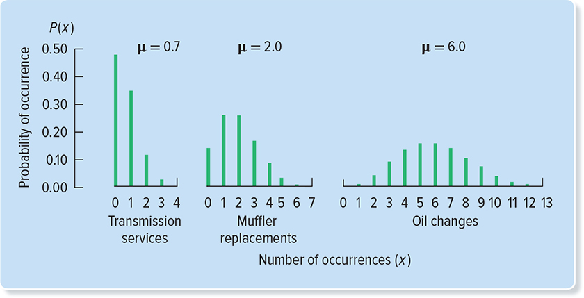

- Poisson distribution is important in practice.
- It is widely used in modeling the **count data**: the number of "success" occurrences in $n$ independent Bernoulli trials.
- Examples
  - The number of emails you receive in a day.
  - The number of customers visiting a bank branch in an hour.
  - The number of patents a received annually by a firm.
  - The number of insurance claims received in an insurance company.
- **Example**. In a popular daily flight from city Townsville to Hong Kong, the aircraft has a capacity of 300 passengers. The airline sells 310 tickets for this flight in order to protect it against no-show passengers. Experience has shown that the probability of a passenger not showing up is 0.05. Assume that passengers who purchased tickets for the same flight act independently of each other.
- What is the probability of at least one passenger having no seat in any given flight?
- The problem is like 310 independent Bernoulli trials with the probability of not showing up at 0.05. There are $n=310$ trials, in each trial a passenger not showing up is counted as a "success", and the probability of "success" is $p=0.05$
- To answer the question, we need to let the random variable $X$ be the number of passengers not showing up for any given flight.
- $X$ then has a binomial distribution with $n=310$ and $p=0.05$. The probability of at least one passenger having no seat is $P(X<10)$, it is the probability of fewer than 10 passengers not showing up. That is also the probability of more than 300 passengers showing up at the gate.
- We can use the Poisson distribution to approximate the binomial distribution since $n$ is large and $p$ is small. The Poisson parameter is $\lambda = np = 310 \cdot 0.05 = 15.5$.
- We know that $P(X<10) = P(X=0) + P(X=1) + \cdots + P(X=9)$, and for the Poisson distribution, $P(X=k) = \frac{\lambda^k}{k!}e^{-\lambda}$ for any number $k$.
- Then $P(X<10) = \frac{\lambda^0 e^{-\lambda}}{0!}+\frac{\lambda^1 e^{-\lambda}}{1!}+\frac{\lambda^2 e^{-\lambda}}{2!}+\cdots+\frac{\lambda^9 e^{-\lambda}}{9!} = 0.055$.
- The probability of at least one passenger is bumped from any given flight is $5.5\%$.

```python
from scipy.stats import poisson, binom
n, p = 310, 0.05
mu = n*p
x = n-300-1
probP = poisson.cdf(x, mu)
probB = binom.cdf(x, n,p)
print('Prob (X<10), if using Poisson, is',probP)
print('Prob (X<10), if using binomial, is',probB)
```

```
Prob (X<10), if using Poisson, is 0.055190456259990216
Prob (X<10), if using binomial, is 0.05089770775898081
```

- **Example**. A store owner observes that, on average, customers arrive his store at a rate of 4.5 persons per hour. Let $X$ be the number of customers arriving the store during a particular one-hour period. Then $X$ approximately has a Poisson distribution with parameter $\lambda = 4.5$.
- Why Poisson? We divide one hour into 3600 seconds, then the arrival rate is 4.5/3600 = 0.00125 customers per second. We assume that customer arrivals in different time periods are independent of each other. Also assume, in each second, there is 0 or 1 customer arriving. The probability of one customer arriving in any second is 0.00125.
- What is the probability at least 3 customers arriving the store in a particular one-hour period?
- $P(X\ge 3) = 1 - P(X<3) =1 - \sum_{k=0}^2 \frac{\lambda^{k}e^{-\lambda}}{k!}$.

```python
from scipy.stats import poisson, binom
mu = 4.5
x = 2
prob = 1.0 - poisson.cdf(x, mu)
print("Prob (X >= 3) is",prob)
```

```
Prob (X >= 3) is 0.8264219290899639
```